# Integration de bloques supplementaires - Classification

Chevalier Mathilde & Malik Jan

07 November 2018

### Import Data sets

```r
library(readxl)
hedonique <- read_xlsx("Saumon.xlsx")
usage <- read_xlsx("Saumon.xlsx", sheet = "Usage")
produits <- read_xlsx("Saumon.xlsx", sheet = "Mesures produits")
```

```r
head(hedonique)
```

| IKIDEN | Country | prod1 | prod2 | prod3 | prod4 | prod5 | prod6 | prod7 | prod8 | prod9 | prod10 | prod11 | prod12 | prod13 | prod14 | prod15 | prod16 | prod17 | prod18 | prod19 | prod20 | prod21 | prod22 | prod23 | prod24 | prod25 | prod26 | prod27 | prod28 | … |
| --- | --- | --- | --- | --- | --- | --- | --- | --- | --- | --- | --- | --- | --- | --- | --- | --- | --- | --- | --- | --- | --- | --- | --- | --- | --- | --- | --- | --- | --- | --- |
| 5101 | Lyon | 0.5433 | 0.5433 | -0.0187 | 0.5433 | 0.5433 | -0.0187 | 1.1054 | -0.5808 | 0.5433 | -0.5808 | -0.0187 | -2.8290 | 0.5433 | -1.7049 | -1.7049 | -1.1428 | 1.6674 | -0.0187 | 0.5433 | -0.5808 | 1.1054 | 1.6674 | -0.5808 | 0.5433 | 0.5433 | -0.0187 | -1.1428 | -0.5808 | … |
| 5102 | Lyon | 0.4685 | -0.3123 | 0.4685 | 0.4685 | 1.2494 | -1.0932 | -0.3123 | 1.2494 | 0.4685 | -0.3123 | 1.2494 | 0.4685 | -0.3123 | 1.2494 | -2.6550 | 1.2494 | -1.8741 | -1.0932 | 0.4685 | -1.0932 | 0.4685 | 1.2494 | -1.0932 | -1.0932 | 0.4685 | -0.3123 | -0.3123 | -0.3123 | … |
| 5103 | Lyon | 0.4354 | 1.3683 | -0.9641 | 0.4354 | 1.3683 | -0.4976 | 0.4354 | -0.4976 | 0.4354 | -0.9641 | -0.9641 | -0.0311 | -0.0311 | -0.9641 | 0.9019 | -2.3635 | 0.4354 | -1.8970 | 0.4354 | 0.9019 | 0.4354 | -1.4305 | 0.4354 | 0.9019 | 1.3683 | -0.4976 | -0.0311 | 1.3683 | … |
| 5106 | Lyon | 1.6920 | 1.6920 | 0.6004 | 1.1462 | 0.6004 | -0.4912 | -1.0371 | -1.5829 | 0.6004 | 0.0546 | -0.4912 | 0.0546 | -1.5829 | -1.0371 | 0.6004 | 0.0546 | -1.0371 | -1.5829 | -1.0371 | -0.4912 | 1.6920 | 0.0546 | 1.1462 | 0.6004 | -0.4912 | 0.0546 | -1.0371 | -0.4912 | … |
| 5107 | Lyon | 0.6167 | -0.2056 | 0.2056 | -0.6167 | -1.4389 | 0.6167 | 0.6167 | 0.2056 | 1.0278 | 0.6167 | -0.6167 | 0.6167 | 1.0278 | 0.2056 | -1.8500 | -0.6167 | 0.6167 | 0.6167 | 1.0278 | 1.4389 | -1.4389 | 1.0278 | 1.4389 | -1.8500 | -1.0278 | -0.6167 | -1.0278 | -1.8500 | … |
| 5108 | Lyon | -0.0165 | 0.9714 | -1.9922 | 0.9714 | -1.0043 | 0.9714 | -0.5104 | 1.4653 | 0.4775 | -0.5104 | 1.4653 | 0.4775 | 0.4775 | 0.9714 | 0.4775 | -0.0165 | 0.4775 | -1.9922 | -1.4983 | -0.5104 | -0.5104 | -0.5104 | 1.4653 | -1.0043 | -0.0165 | -1.0043 | -0.0165 | -1.4983 | … |

```r
head(produits)
```

| Products | water | lipid | TVBN | TMA | salt | phenol | pH | total viable count | lactic flora | lactobacilli | brochothrix | yeast | enterobacteriaceae | L* | a* | b* | France | Germany | Italy | UK | DK | Belgium | Norway | Scotland | Ireland |
| --- | --- | --- | --- | --- | --- | --- | --- | --- | --- | --- | --- | --- | --- | --- | --- | --- | --- | --- | --- | --- | --- | --- | --- | --- | --- |
| prod1 | -0.8644 | 1.1375 | -0.7629 | -0.8717 | -0.1471 | -0.3776 | 1.5412 | 0.1112 | 0.6665 | 1.1382 | 0.5461 | 0.7729 | 0.8314 | 0.9917 | -0.6467 | -0.4567 | 1.1435 | -0.5 | -0.1857 | -0.3922 | -0.3333 | -0.3333 | 0.8745 | -0.6547 | -0.3922 |
| prod2 | -1.1476 | 0.7036 | 0.2357 | 0.3204 | 0.1626 | 0.0112 | 1.2098 | 0.4302 | -0.4514 | 0.1290 | -0.7559 | 1.2034 | 0.5998 | 0.8542 | 0.5297 | 0.9551 | 1.1435 | -0.5 | -0.1857 | -0.3922 | -0.3333 | -0.3333 | 0.8745 | -0.6547 | -0.3922 |
| prod3 | -0.4172 | 0.3378 | 0.4354 | 1.2144 | 0.3174 | 0.4001 | 0.3812 | 0.8225 | 0.8725 | 0.4088 | 0.6465 | 0.2875 | 0.2524 | -0.8548 | 0.3927 | 0.2813 | 1.1435 | -0.5 | -0.1857 | -0.3922 | -0.3333 | -0.3333 | 0.8745 | -0.6547 | -0.3922 |
| prod4 | -0.8147 | -0.0961 | -0.5632 | -0.8717 | 0.3174 | -0.4554 | 0.2154 | -0.2432 | -1.5861 | -1.0624 | -0.7559 | -1.0340 | -1.5793 | 0.3020 | 1.7439 | 3.3236 | 1.1435 | -0.5 | -0.1857 | -0.3922 | -0.3333 | -0.3333 | -1.1435 | 1.5275 | -0.3922 |
| prod5 | -1.6991 | 0.0366 | -0.7629 | -0.8717 | 2.1752 | -0.3776 | -0.2817 | -1.5584 | -1.5861 | -1.0624 | -0.7559 | -1.0340 | -0.9582 | -1.3485 | 0.7341 | 0.5485 | -0.8745 | 2.0 | -0.1857 | -0.3922 | -0.3333 | -0.3333 | 0.8745 | -0.6547 | -0.3922 |
| prod6 | -0.9886 | 0.9653 | -0.7629 | -0.8717 | 0.0077 | 0.6594 | 1.0441 | -2.5977 | -1.5861 | -1.0624 | -0.7559 | -1.0340 | -1.5793 | -0.4322 | 0.4016 | 0.4278 | 1.1435 | -0.5 | -0.1857 | -0.3922 | -0.3333 | -0.3333 | -1.1435 | -0.6547 | 2.5495 |

```r
head(usage)
```

| IKIDEN | Who | Frequence | When | Taste | Healthy | Pleasure | No preparation | Ways | Guest | Authentic | Not expensive | Supermarket | Deli | Caterer | Fish shop | Market | Mobile van | Everyday | Special | Day snack | Evening snack | Aperitif | Starter | Salad | Cooked meal | Sandwich | Main | Vegetable | Lemon | … |
| --- | --- | --- | --- | --- | --- | --- | --- | --- | --- | --- | --- | --- | --- | --- | --- | --- | --- | --- | --- | --- | --- | --- | --- | --- | --- | --- | --- | --- | --- | --- |
| 5101 | Adults | 5 to 6 times a year | Special celebration | Comp. Agree | Most. Agree | Comp. Agree | Neither | Neither | Comp. Agree | Most. Agree | Most. Disa. | Yes | No | No | No | No | No | No | Yes | No | No | Yes | Yes | No | No | No | No | Yes | No | … |
| 5102 | Both | Once every 2 weeks | Only the winter | Most. Agree | Comp. Agree | Comp. Agree | Most. Agree | Comp. Agree | Comp. Agree | Most. Agree | Most. Disa. | Yes | No | No | No | No | No | Yes | No | No | Yes | Yes | No | Yes | No | Yes | No | No | No | … |
| 5103 | Both | 5 to 6 times a year | Special celebration | Comp. Agree | Most. Agree | Comp. Agree | Comp. Agree | Comp. Agree | Comp. Agree | Comp. Agree | Most. Agree | Yes | No | Yes | No | No | No | No | Yes | No | Yes | Yes | Yes | Yes | No | No | No | No | No | … |
| 5106 | Both | Once a month | All year round | Comp. Agree | Comp. Agree | Comp. Agree | Comp. Agree | Comp. Agree | Comp. Agree | Comp. Agree | Neither | Yes | No | No | No | No | No | Yes | No | No | No | No | Yes | No | No | No | No | No | Yes | … |
| 5107 | Adults | Once every 2 weeks | All year round | Comp. Agree | Most. Agree | Comp. Agree | Neither | Neither | Comp. Agree | Most. Agree | Neither | Yes | No | No | No | No | No | Yes | Yes | No | No | No | Yes | No | No | No | No | No | Yes | … |
| 5108 | Both | Once every 2 weeks | All year round | Comp. Agree | Most. Agree | Comp. Agree | Most. Agree | Comp. Agree | Comp. Agree | Most. Agree | Most. Disa. | Yes | No | No | No | No | No | Yes | Yes | No | No | Yes | Yes | No | No | No | No | No | No | … |

> Analyses

Nous allons effectuer dans un premier temps des analyses factorielles et une classification hiérarchique sur composantes principales à partir des résultats:

- sur les données hédoniques
- sur les données hédoniques + bloque des usages en illustratif
- Juxtaposition
- sur les données hédoniques + bloque des produits en illustratif
- Superposition *sur les données hédoniques + 4ième bloque
- Interaction Produit et Usage

## Données hédoniques

```r
#ACP
library(FactoMineR)
res0 <- PCA(hedonique[,-c(1,2)])
```

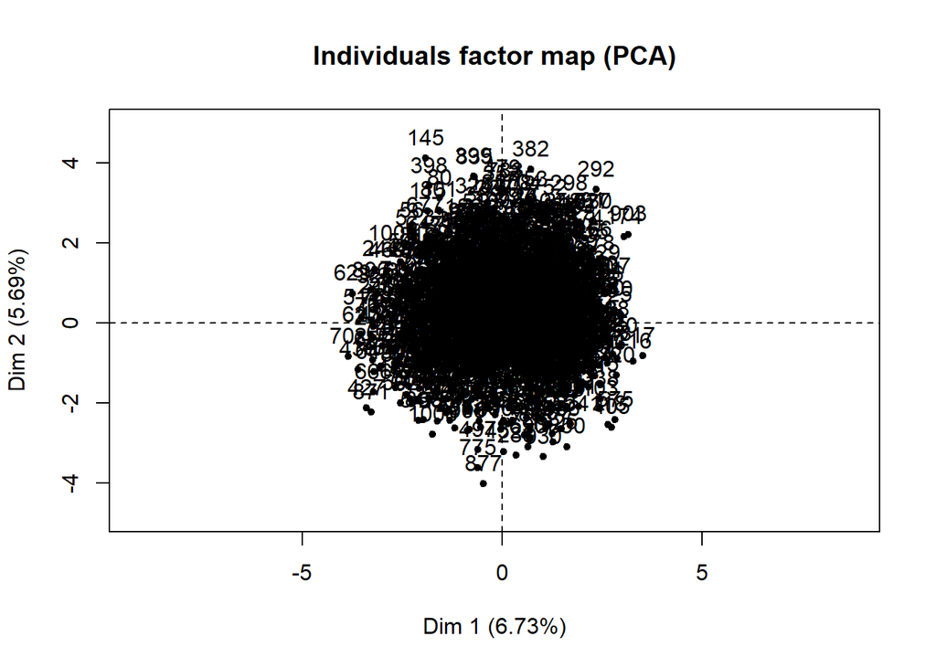

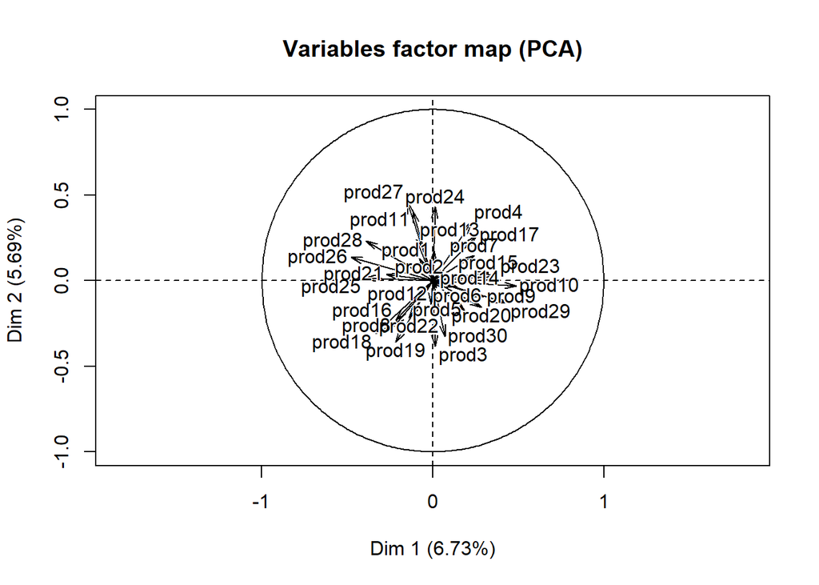

> Pourquoi avoir enlever la variabe sur l’origine des produit ?

```r
library(factoextra)
```

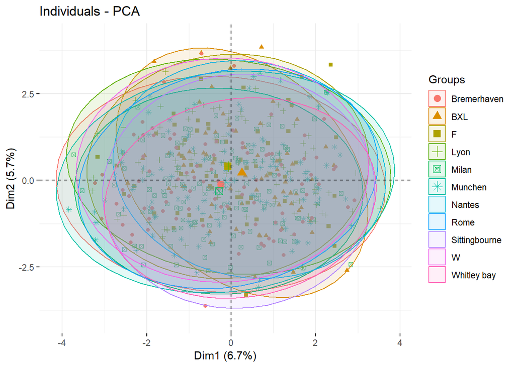

```r
fviz_pca_ind(res0,
             geom.ind = "point", # Montre les points seulement (mais pas le "text")
             col.ind = hedonique$Country, # colorer by groups
             addEllipses = TRUE, # Ellipses de concentration
             legend.title = "Groups"
             )
```

On observe que l’origine du consommateur n’a pas l’air d’avoir une influence sur la valeur hédonique. On enlèvera la variable origine pour la suite de l’analyse.

A partir des résultat de l’ACP on peut effectuer une classification des individus.

```r
#Classification
res.hcpc0 = HCPC(res0, nb.clust = 3)
```

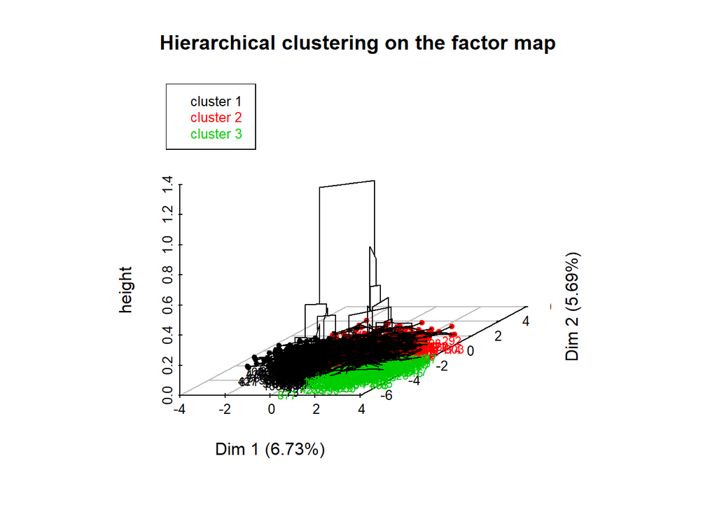

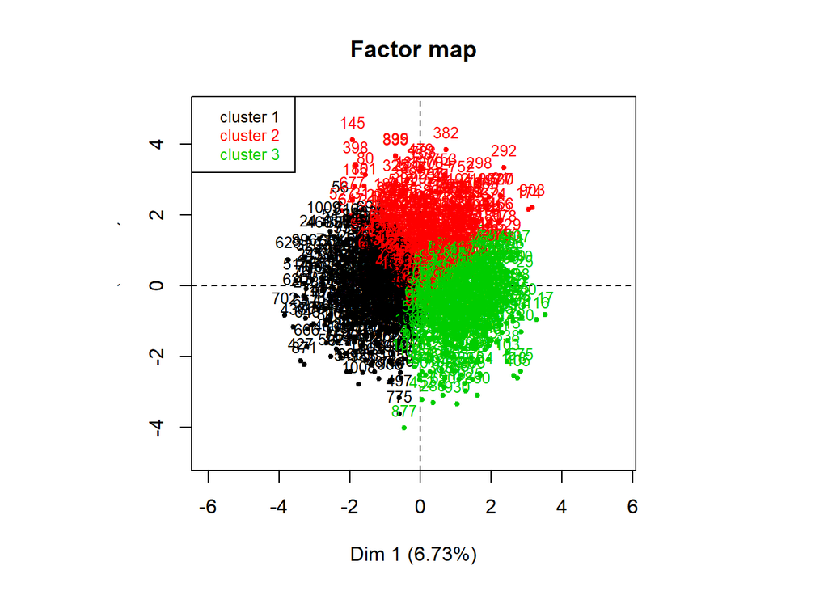

```r
res.hcpc0$desc.var
```

```
##
## Link between the cluster variable and the quantitative variables
## ================================================================
##               Eta2      P-value
## prod10 0.176168250 2.479811e-45
## prod26 0.158508303 1.889786e-40
## prod29 0.135053449 4.020811e-34
## prod27 0.130801253 5.409018e-33
## prod16 0.126914654 5.755069e-32
## prod28 0.122242389 9.739577e-31
## prod25 0.101448747 2.386232e-25
## prod4  0.100906262 3.285759e-25
## prod20 0.098849898 1.102763e-24
## prod7  0.095320532 8.754051e-24
## prod17 0.092859499 3.694158e-23
## prod8  0.087828119 6.928521e-22
## prod23 0.082847848 1.241470e-20
## prod18 0.073290356 3.021007e-18
## prod11 0.066661598 1.320510e-16
## prod3  0.060238282 5.005037e-15
## prod15 0.059072186 9.657008e-15
## prod13 0.057461545 2.390625e-14
## prod24 0.054454804 1.293049e-13
## prod30 0.054314490 1.398844e-13
## prod19 0.049254993 2.365638e-12
## prod21 0.049097446 2.582779e-12
## prod9  0.048553597 3.496989e-12
## prod12 0.043558763 5.609124e-11
## prod5  0.029163375 1.539786e-07
## prod22 0.025278736 1.278302e-06
## prod6  0.015234139 2.927398e-04
## prod2  0.010585643 3.551814e-03
## prod1  0.009304576 7.051528e-03
## prod14 0.008855040 8.968170e-03
##
## Description of each cluster by quantitative variables
## =====================================================
## $`1`
##            v.test Mean in category Overall mean sd in category Overall sd
## prod25   9.759476       0.20700401 -0.226143974      1.0111730  1.0656099
```

[output cut: 135 more lines]

```
## prod30 7.564437e-07
## prod12 4.139156e-04
## prod14 2.323311e-02
## prod6  4.496407e-02
## prod1  3.437883e-02
## prod2  4.435964e-03
## prod18 3.004622e-03
## prod24 5.037264e-06
## prod21 2.850070e-08
## prod13 1.994962e-09
## prod11 1.268007e-13
## prod25 4.226371e-16
## prod27 7.380510e-28
## prod28 7.604511e-30
## prod26 5.133585e-36
```

> Observations des résultats :
- Le groupe 3 est former des individus ayant des valeurs (relativements) fortes sur les mesures hédoniques du produit 10 et (relativements) faibles pour produit 26
- …

## Données hédoniques en intégrant le bloque usage

Juxtaposition Hedonique et Usage : Actif et Illustratif

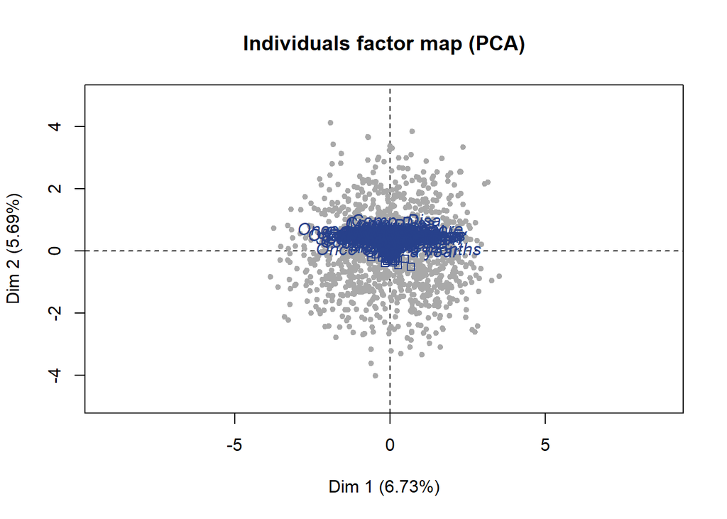

```r
#Juxtaposition
HedUsa <- cbind(hedonique, usage[,-1])
HedUsa <- HedUsa[,-c(1,2)]
#ACP
res1 <- PCA(HedUsa, quali.sup = 31:98, graph=FALSE)
plot.PCA(res1,label="quali", col.ind = "darkgrey", col.quali = "royalblue4")
```

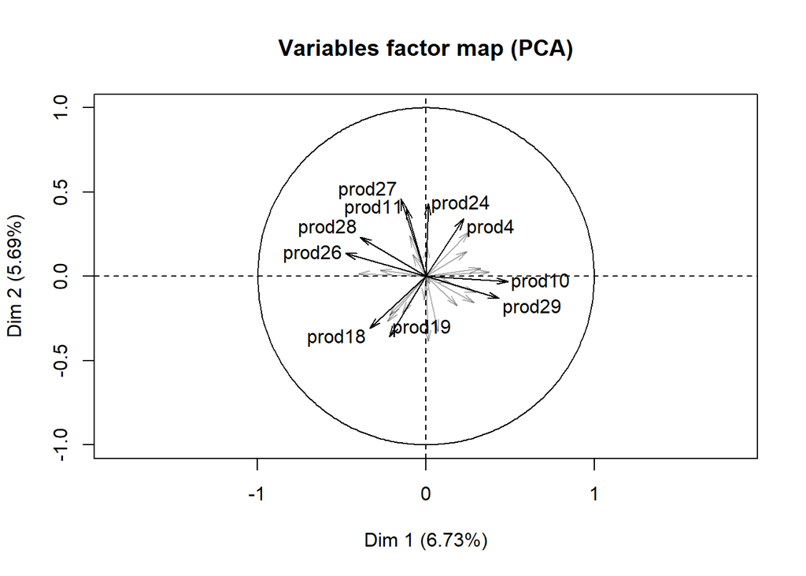

```r
plot.PCA(res1,choix="var", select="contrib 10")
```

Le graphqiue des individus est difficile à lire mais on peut effectuer une classification pour mieux comprendre le lien entre les groupes d’individus des données hédoniques et des variables supplémentaires concernant l’usage d’un produit de cette individu.

```r
#Classification
res.hcpc1 = HCPC(res1, nb.clust = 3)
```

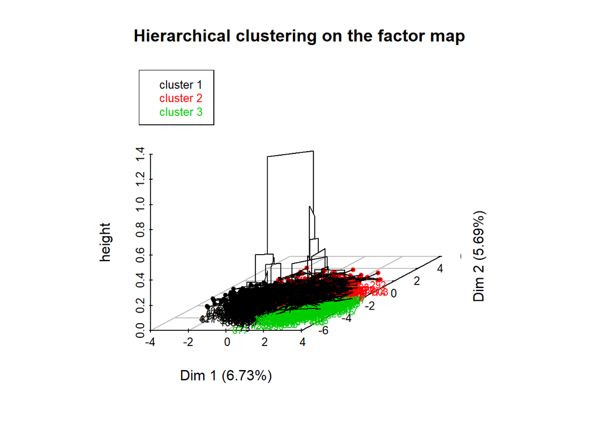

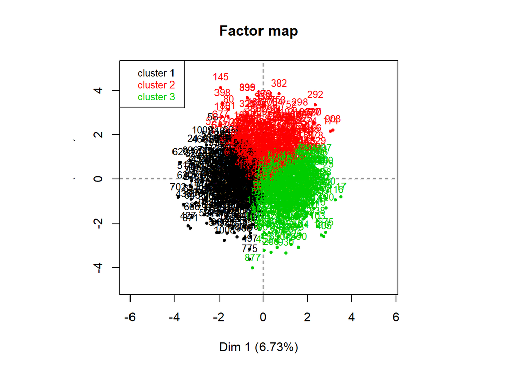

```r
res.hcpc1$desc.var
```

```
##
## Link between the cluster variable and the categorical variables (chi-square test)
## =================================================================================
##                           p.value df
## Not.too.salty        3.994099e-05  2
## Appetising           8.494705e-03  2
## Firm.texture         1.658330e-02  2
## Characteristic.taste 2.227731e-02  2
## Wild                 2.922109e-02  2
## Not.expensive        3.191417e-02  8
## Glossiness           3.678832e-02  2
## Healthy              3.828854e-02  8
##
## Description of each cluster by the categories
## =============================================
## $`1`
##                            Cla/Mod   Mod/Cla    Global     p.value
## Not.too.salty=Yes         41.17647 43.048128 36.782690 0.001917170
## Firm.texture=No           37.37981 83.155080 78.269050 0.004047093
## Glossiness=Yes            41.11842 33.422460 28.598307 0.010954382
## Wild=Yes                  42.65403 24.064171 19.849483 0.012114617
## Horseradish=Yes           42.77778 20.588235 16.933208 0.020774529
## Smooth.texture=Yes        43.31210 18.181818 14.769520 0.022674671
## Not.expensive=Comp. Agree 51.16279  5.882353  4.045155 0.029793877
## Evening.snack=Yes         39.37824 40.641711 36.312324 0.031376274
## Main=No                   36.80297 79.411765 75.917215 0.048833366
## Main=Yes                  30.07812 20.588235 24.082785 0.048833366
## Not.expensive=Comp. Disa. 27.20588  9.893048 12.793979 0.035327505
## Evening.snack=No          32.79173 59.358289 63.687676 0.031376274
## Smooth.texture=No         33.77483 81.818182 85.230480 0.022674671
## Horseradish=No            33.63533 79.411765 83.066792 0.020774529
## Wild=No                   33.33333 75.935829 80.150517 0.012114617
## Glossiness=No             32.80632 66.577540 71.401693 0.010954382
## Firm.texture=Yes          27.27273 16.844920 21.730950 0.004047093
## Not.too.salty=No          31.69643 56.951872 63.217310 0.001917170
##                              v.test
## Not.too.salty=Yes          3.102772
## Firm.texture=No            2.874468
## Glossiness=Yes             2.544151
## Wild=Yes                   2.508788
```

[output cut: 228 more lines]

```
## prod30 7.564437e-07
## prod12 4.139156e-04
## prod14 2.323311e-02
## prod6  4.496407e-02
## prod1  3.437883e-02
## prod2  4.435964e-03
## prod18 3.004622e-03
## prod24 5.037264e-06
## prod21 2.850070e-08
## prod13 1.994962e-09
## prod11 1.268007e-13
## prod25 4.226371e-16
## prod27 7.380510e-28
## prod28 7.604511e-30
## prod26 5.133585e-36
```

> Observations :

Idem que avant, plus : * Groupe 3 avec la variable caractérisant l’aspect salée du produit (ces individus semblent préférer un saumon lorsqu’il est plus salé qu’un autre). * …

## Données hédoniques en intégrant le bloque produit

**Superpostion Hedonique et transposée Produit : Actifs et Illustratifs** On force cette superposition des mesures des produits hédoniques et de la transposée des données sur les produits (non hédoniques) et on obtient donc des indivudus fictifs (exemple : **Mister Salty**, individu fictif qui ne voit qu’au travers d’une seule dimension dans son jugement, la dimension salée).

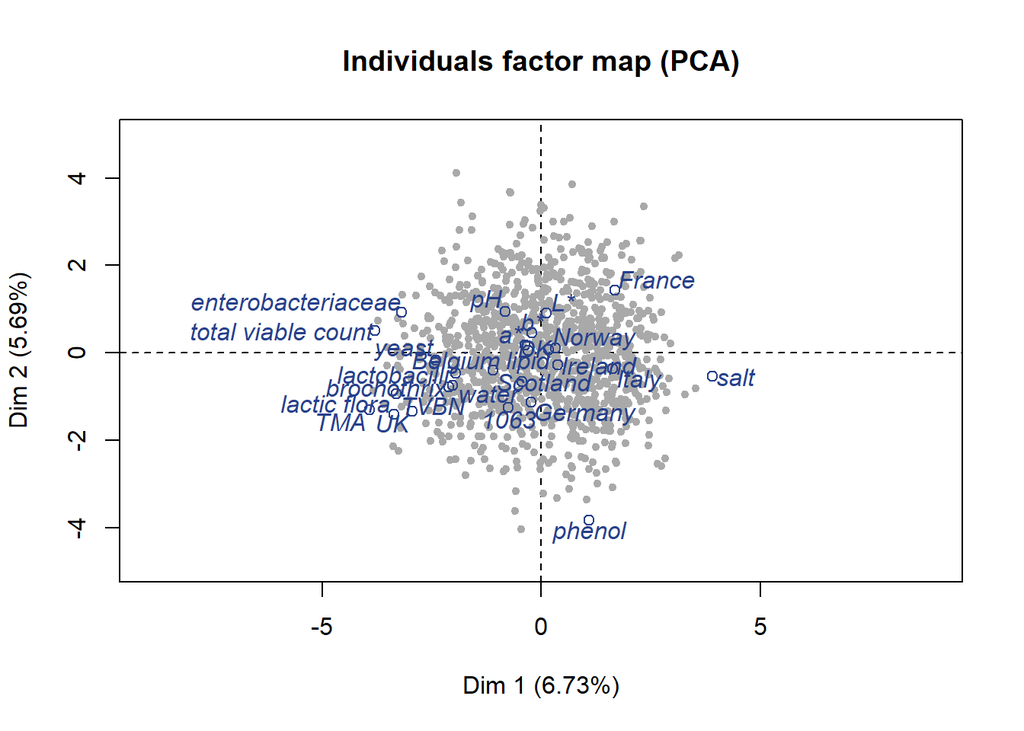

```r
#Superposition
tProd <- t(produits)[-1,]
colnames(tProd) <- colnames(hedonique[,-(1:2)])
HedProd <- rbind(hedonique[,-c(1,2)],tProd)
HedProd <- apply(HedProd, 1, FUN=as.numeric)
HedProd <- as.data.frame(t(HedProd))
colnames(HedProd) <- colnames(hedonique[,-(1:2)])
#ACP
res2 <- PCA(HedProd, ind.sup = 1063:1088, graph = FALSE)
plot.PCA(res2, col.ind="darkgrey", col.ind.sup = "royalblue4", label="ind.sup")
```

```r
#Classification
res.hcpc2 = HCPC(res2, nb.clust = 3)
```

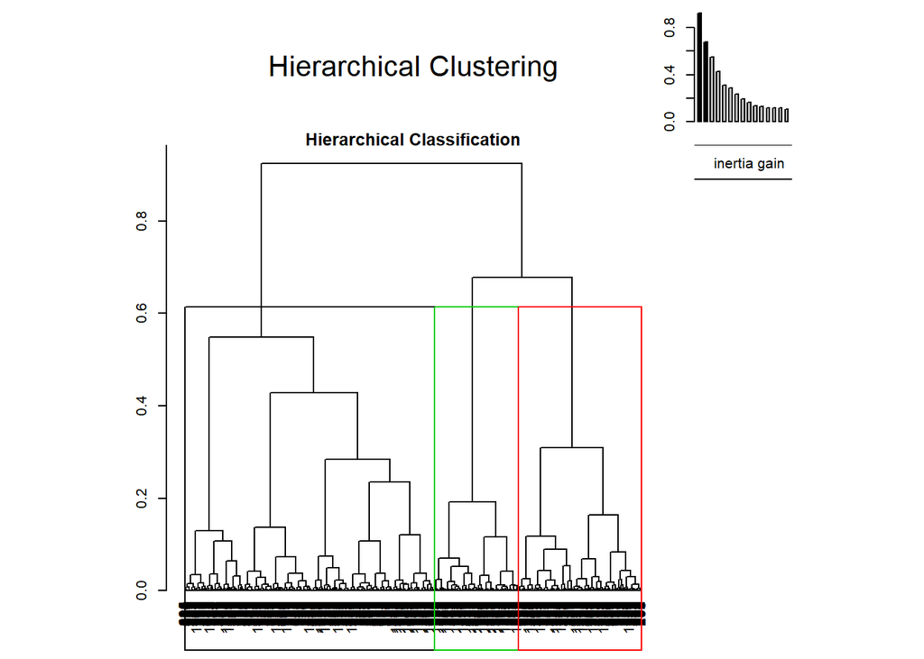

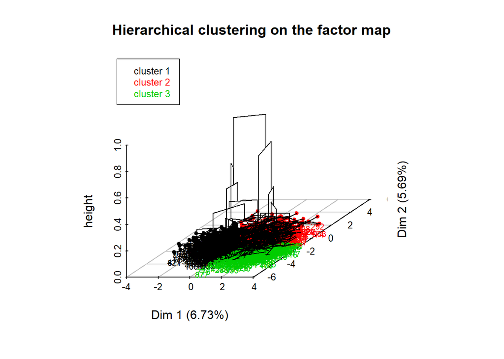

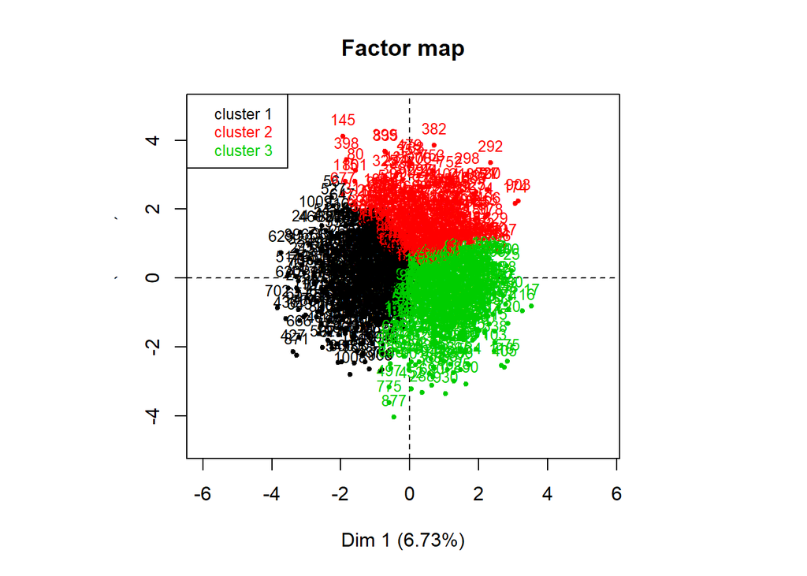

```r
res.hcpc2$desc.var
```

```
##
## Link between the cluster variable and the quantitative variables
## ================================================================
##               Eta2      P-value
## prod10 0.183743075 2.052732e-47
## prod27 0.140935297 1.166006e-35
## prod26 0.133933555 8.577625e-34
## prod29 0.132331701 2.281920e-33
## prod28 0.116140879 4.072151e-29
## prod24 0.107850894 5.709879e-27
## prod18 0.101169554 2.967439e-25
## prod25 0.098995561 1.066375e-24
## prod11 0.091830115 7.070948e-23
## prod19 0.087962968 6.708173e-22
## prod17 0.087269916 1.002957e-21
## prod16 0.084769368 4.269968e-21
## prod20 0.076323211 5.531669e-19
## prod8  0.075977541 6.743697e-19
## prod4  0.074024592 2.062578e-18
## prod15 0.069610716 2.558341e-17
## prod23 0.067398815 8.995230e-17
## prod30 0.066060148 1.922479e-16
## prod9  0.063521848 8.091064e-16
## prod3  0.062153625 1.752820e-15
## prod7  0.056282217 4.774332e-14
## prod22 0.051008598 9.128009e-13
## prod13 0.042322066 1.136881e-10
## prod5  0.040937794 2.442690e-10
## prod21 0.040394108 3.297567e-10
## prod1  0.031978991 3.357319e-08
## prod6  0.018604789 4.801349e-05
## prod12 0.006514561 3.140635e-02
##
## Description of each cluster by quantitative variables
## =====================================================
## $`1`
##            v.test Mean in category Overall mean sd in category Overall sd
## prod26  10.286103       0.40362044  0.004186327      0.8813629  0.9931087
## prod25  10.106185       0.19573416 -0.225476616      1.0185949  1.0658958
## prod18   8.935662       0.25867928 -0.125063739      1.0438500  1.0982881
```

[output cut: 121 more lines]

```
## prod30 2.160288e-10
## prod3  1.553959e-08
## prod15 3.385973e-07
## prod6  2.792161e-03
## prod14 3.101036e-02
## prod19 4.087437e-02
## prod1  6.452078e-06
## prod21 2.196964e-07
## prod13 4.898552e-08
## prod25 3.848775e-12
## prod24 1.756417e-12
## prod11 2.478356e-19
## prod26 1.524994e-26
## prod28 4.097387e-28
## prod27 1.772679e-31
```

> Observations :

Idem que avant, en plus : * **Mister Salty** semble être proche (en terme de distance) des idividus du groupe 3 qui est caractérisé par les mesures hédoniques du produit 10, … * …

## Données hédoniques en intégrant les blogues usage et produit (interaction)

Seul les données hédoniques seront en actif de l’ACP.

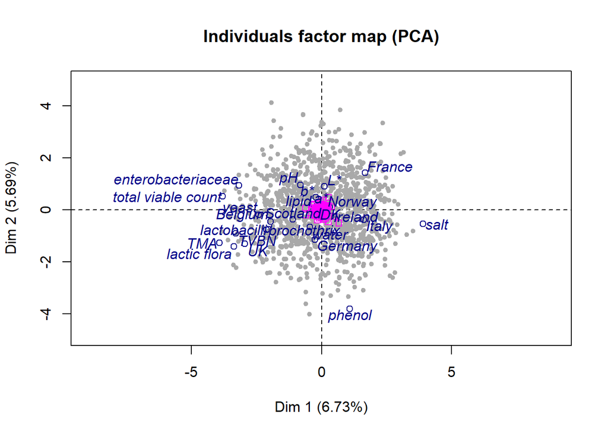

```r
#Création jeux de données (juxtaposition et superposition)
Mat0 <- matrix(ncol=68, nrow=25, "None") #car variables illustratives de type qualitatives
mat0 <- as.data.frame(Mat0)
colnames(Mat0) <- colnames(usage[,-1])
UsaMat <- rbind(usage[,-1], Mat0)
Bloc4 <- cbind(HedProd, UsaMat)
#ACP
res3 <- PCA(Bloc4, ind.sup=1064:1088,quali.sup=31:98, graph = FALSE)
plot.PCA(res3,col.ind="darkgrey", col.ind.sup = "darkblue", label="ind.sup")
```

```r
#Classification
res.hcpc3 = HCPC(res3, nb.clust = 3)
```

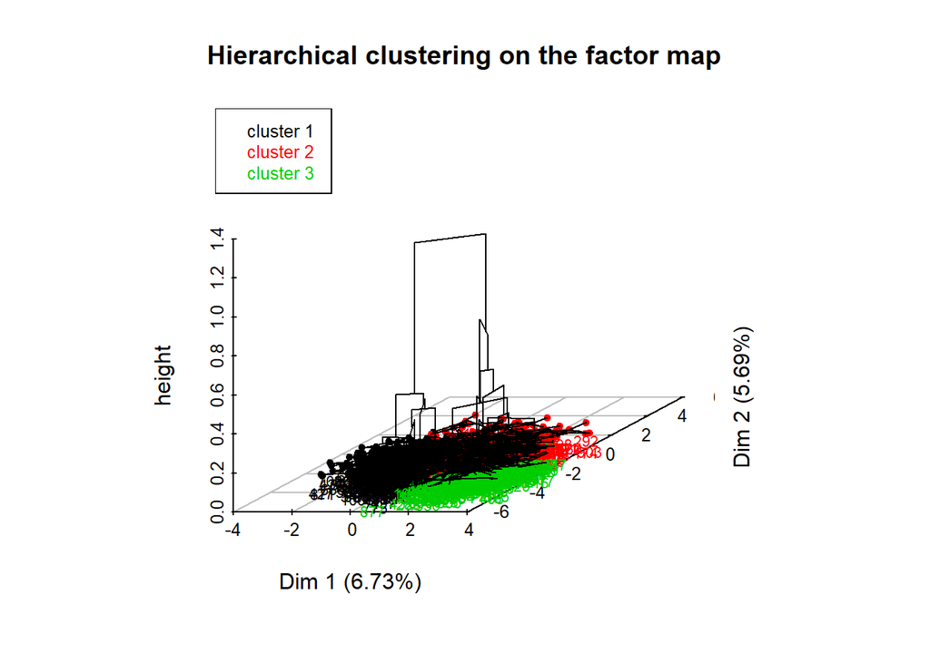

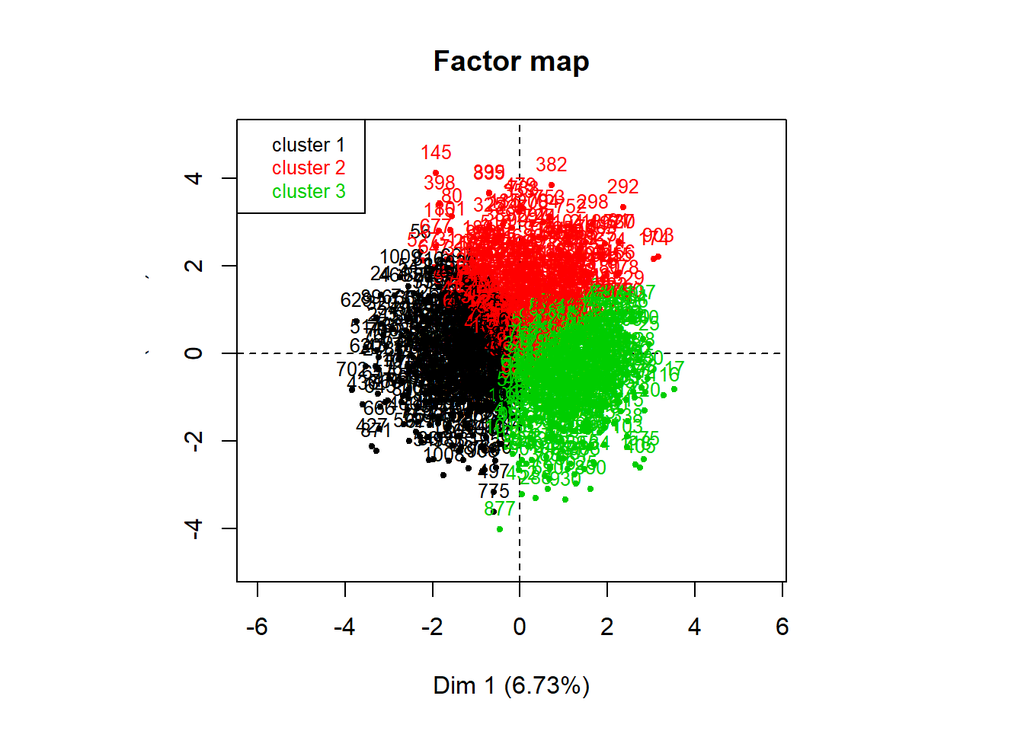

```r
res.hcpc3$desc.var
```

```
##
## Link between the cluster variable and the categorical variables (chi-square test)
## =================================================================================
##                           p.value df
## Not.too.salty        3.994099e-05  2
## Appetising           8.494705e-03  2
## Firm.texture         1.658330e-02  2
## Characteristic.taste 2.227731e-02  2
## Wild                 2.922109e-02  2
## Not.expensive        3.191417e-02  8
## Glossiness           3.678832e-02  2
## Healthy              3.828854e-02  8
##
## Description of each cluster by the categories
## =============================================
## $`1`
##                            Cla/Mod   Mod/Cla    Global     p.value
## Not.too.salty=Yes         41.17647 43.048128 36.782690 0.001917170
## Firm.texture=No           37.37981 83.155080 78.269050 0.004047093
## Glossiness=Yes            41.11842 33.422460 28.598307 0.010954382
## Wild=Yes                  42.65403 24.064171 19.849483 0.012114617
## Horseradish=Yes           42.77778 20.588235 16.933208 0.020774529
## Smooth.texture=Yes        43.31210 18.181818 14.769520 0.022674671
## Not.expensive=Comp. Agree 51.16279  5.882353  4.045155 0.029793877
## Evening.snack=Yes         39.37824 40.641711 36.312324 0.031376274
## Main=No                   36.80297 79.411765 75.917215 0.048833366
## Main=Yes                  30.07812 20.588235 24.082785 0.048833366
## Not.expensive=Comp. Disa. 27.20588  9.893048 12.793979 0.035327505
## Evening.snack=No          32.79173 59.358289 63.687676 0.031376274
## Smooth.texture=No         33.77483 81.818182 85.230480 0.022674671
## Horseradish=No            33.63533 79.411765 83.066792 0.020774529
## Wild=No                   33.33333 75.935829 80.150517 0.012114617
## Glossiness=No             32.80632 66.577540 71.401693 0.010954382
## Firm.texture=Yes          27.27273 16.844920 21.730950 0.004047093
## Not.too.salty=No          31.69643 56.951872 63.217310 0.001917170
##                              v.test
## Not.too.salty=Yes          3.102772
## Firm.texture=No            2.874468
## Glossiness=Yes             2.544151
## Wild=Yes                   2.508788
```

[output cut: 228 more lines]

```
## prod30 7.570499e-07
## prod12 4.139772e-04
## prod14 2.322499e-02
## prod6  4.493668e-02
## prod1  3.438518e-02
## prod2  4.435122e-03
## prod18 3.003117e-03
## prod24 5.037596e-06
## prod21 2.847018e-08
## prod13 1.995877e-09
## prod11 1.267976e-13
## prod25 4.219113e-16
## prod27 7.377113e-28
## prod28 7.587026e-30
## prod26 5.128224e-36
```

> Observations :
- Les individus du groupe 3 semblent préférer les produits (relativement) salés (tq le produit 10)
- **Mister Salty** se trouve à une faible distance par rapport aux individus du groupe 3, cohérent vu ce qui à était dit précédement
- …

> Cohérence ?

Désormais nous devont vérifier si il y a une cohérence entre les individus fictifs et les réponses des individus (comme par exemple : y a t’il une cohérence entre **Mister Salty** et les réponses des individus appartenant au groupe 3?)

Pour cela nous allons effectué une **ACP** puis une **CHCP** sur une base de données en 4 bloques, composée de : * Bloque 1 : données hédoniques ayant en lignes les produits et en colonnes les facteurs * Bloque 2 : données produits ayant les mêmes lignes et en colonnes les caractéristques + Juxtaposition * Bloque 3 : données usage ayant en lignes les usages (qui deviendrons des **produits fictifs**) et en colonnes les juges + Superposition Bloque 4 : interaction produit et usage

```r
#Création jeux de données à analyser
hBis <- as.data.frame(t(hedonique[,-c(1,2)]))
uBis <- as.data.frame(t(usage[, -1]))
pBis <- produits[,-1]
Mat0 <- matrix(ncol=25, nrow=68, 0) # car quantitatives
Mat0 <- as.data.frame(Mat0)
colnames(Mat0) <- colnames(pBis)

#Superpositions
huBis <- as.data.frame(rbind(hBis, uBis))
pMat0 <- as.data.frame(rbind(pBis, Mat0))
#Juxtaposition
NewBlocs <- as.data.frame(cbind(huBis, pMat0))
#Numerisation
NewBlocs[1:30,] <- apply(NewBlocs[1:30,], 1, as.numeric)
NewBlocs[,1:1063] <- apply(NewBlocs[,1:1063], 2, as.numeric)
```

[output not shown]

[output cut: 3133 more lines]

[output not shown]

```r
#ACP
#head(NewBlocs)
resBis <- PCA(NewBlocs, ind.sup = 31:98, quanti.sup = 1064:1088)
```

```
FALSE Warning in PCA(NewBlocs, ind.sup = 31:98, quanti.sup = 1064:1088):
FALSE Missing values are imputed by the mean of the variable: you should use the
FALSE imputePCA function of the missMDA package
```

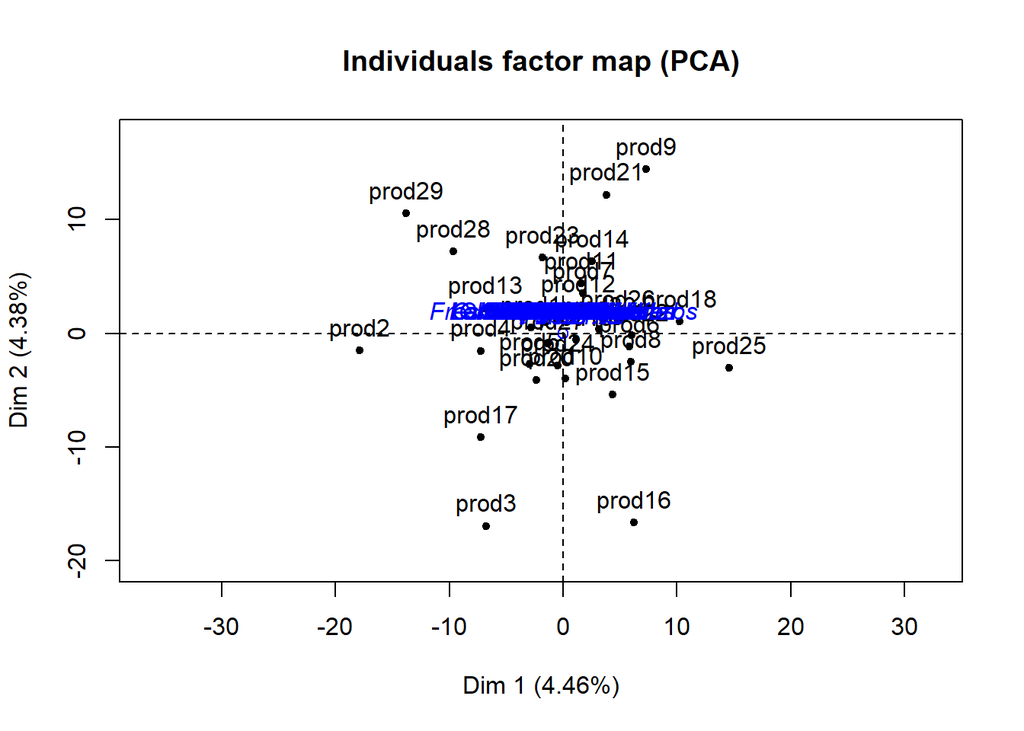

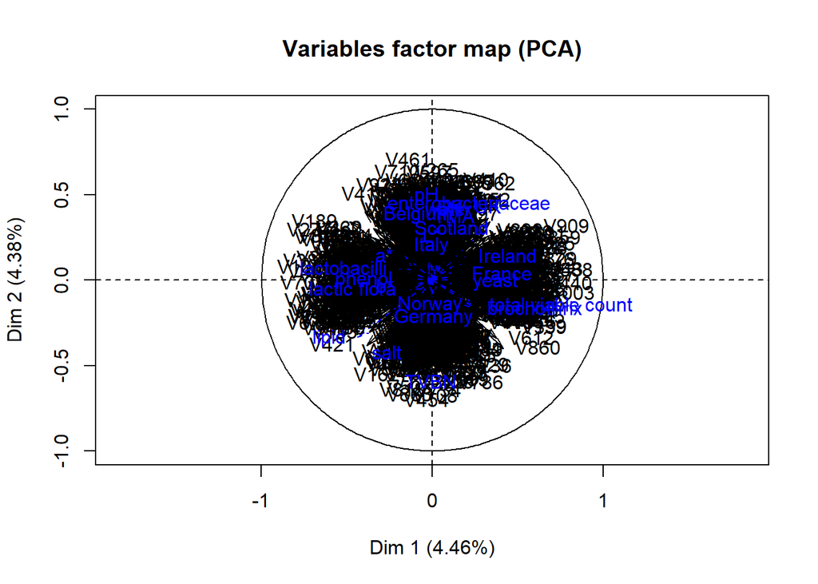